# ggplot2: 14 Build a plot layer by layer

This notebook is based on exercises completed from [ggplot2: Elegant Graphics for Data Analysis](https://ggplot2-book.org/index.html).

```r
library(tidyverse)
```

## 14.3.1 Data Exercises

1. The first two arguments to ggplot are data and mapping. The first two arguments to all layer functions are mapping and data. Why does the order of the arguments differ? (Hint: think about what you set most commonly.)

They are in order of most commonly used. In ggplot2, the data comes first and in geoms, usually the data is default to the ggplot call so the mappings are used most often.

2. The following code uses dplyr to generate some summary statistics about each class of car. Use the data to recreate this plot:

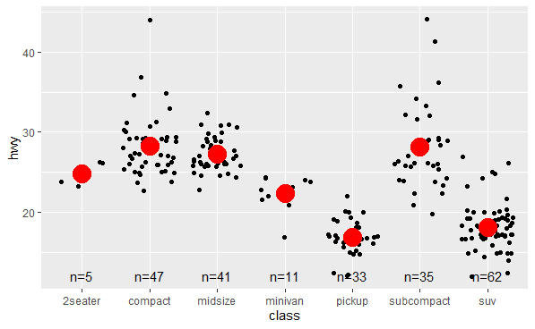

```r
class <- mpg %>%
  group_by(class) %>%
  summarise(n = n(), hwy = mean(hwy),
            .groups = "drop")

# create annotation vector
classMeans <- str_c("n=", class$n, sep = "")

ggplot() +
  geom_jitter(aes(class, hwy), data = mpg) +
  geom_point(aes(class, hwy), data = class, color = "red", size = 7) +
  geom_text(aes(class, min(mpg$hwy), label = classMeans), data = class)
```

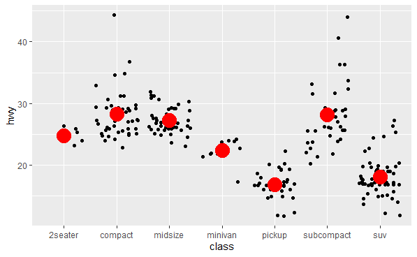

```r
# alternative version from later in chapter
ggplot(mpg, aes(class, hwy)) +
  geom_jitter() +
  geom_point(stat = "summary", fun = "mean", colour = "red", size = 7)
```

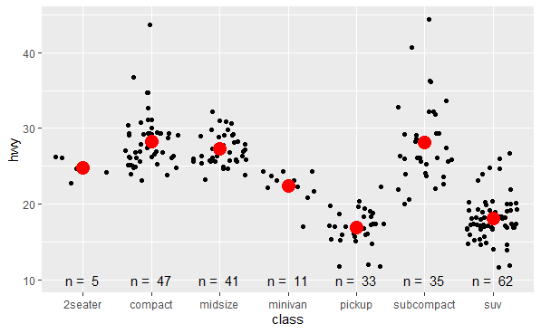

```r
# AM solution with label as new column
class <- mpg %>%
  group_by(class) %>%
  summarise(n = n(), hwy = mean(hwy),
            .groups = "drop") %>%
  mutate(nlabel = paste("n = ",n))

ggplot(mpg, aes(class, hwy)) +
  geom_point(position = "jitter") +
  geom_point(data = class,colour = "red",size = 5) +
  geom_text(data = class,aes(label = nlabel, y = 10))
```

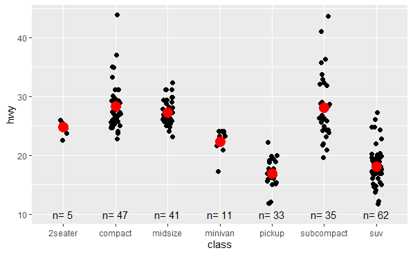

```r
#YX solution
t<-paste("n=",class$n)
ggplot(mpg,aes(x=class,y=hwy))+
geom_jitter(width = 0.1, size=2)+ # use width to constrain the points
geom_point(aes(x=class,y=hwy),data = class,colour="red",size=5)+
geom_text(aes(label=t,y=10),data=class)
```